# Chapter 6. Analysis of longitudinal data

## Random intercept model

```r
install.packages("lme4")
```

```r
library(lme4)
BPRS_ref <- lmer(bprs ~ week + treatment + (1 | subject), data = BPRSL, REML = FALSE)
summary(BPRS_ref)
```

```
## Linear mixed model fit by maximum likelihood  ['lmerMod']
## Formula: bprs ~ week + treatment + (1 | subject)
##    Data: BPRSL
##
##      AIC      BIC   logLik deviance df.resid
##   2748.7   2768.1  -1369.4   2738.7      355
##
## Scaled residuals:
##     Min      1Q  Median      3Q     Max
## -3.0481 -0.6749 -0.1361  0.4813  3.4855
##
## Random effects:
##  Groups   Name        Variance Std.Dev.
##  subject  (Intercept)  47.41    6.885
##  Residual             104.21   10.208
## Number of obs: 360, groups:  subject, 20
##
## Fixed effects:
##             Estimate Std. Error t value
## (Intercept)  46.4539     1.9090  24.334
## week         -2.2704     0.2084 -10.896
## treatment2    0.5722     1.0761   0.532
##
## Correlation of Fixed Effects:
##            (Intr) week
## week       -0.437
## treatment2 -0.282  0.000
```

This model allows the linear regression fit for each bprs to differ in intercept from other bprs. The variance of bprs between subjects is large, which is also showing variability of their respective intercepts. Statistics of week and treatment2 are very similar to their statistics in the first model BPRS_reg.

## Random intercept and slope model

```r
library(lme4)
BPRS_ref1 <- lmer(bprs ~ week + treatment + (week | subject), data = BPRSL, REML = FALSE)
summary(BPRS_ref1)
```

```
## Linear mixed model fit by maximum likelihood  ['lmerMod']
## Formula: bprs ~ week + treatment + (week | subject)
##    Data: BPRSL
##
##      AIC      BIC   logLik deviance df.resid
##   2745.4   2772.6  -1365.7   2731.4      353
##
## Scaled residuals:
##     Min      1Q  Median      3Q     Max
## -2.8919 -0.6194 -0.0691  0.5531  3.7977
##
## Random effects:
##  Groups   Name        Variance Std.Dev. Corr
##  subject  (Intercept) 64.8222  8.0512
##           week         0.9609  0.9803   -0.51
##  Residual             97.4304  9.8707
## Number of obs: 360, groups:  subject, 20
##
## Fixed effects:
##             Estimate Std. Error t value
## (Intercept)  46.4539     2.1052  22.066
## week         -2.2704     0.2977  -7.626
## treatment2    0.5722     1.0405   0.550
##
## Correlation of Fixed Effects:
##            (Intr) week
## week       -0.582
## treatment2 -0.247  0.000
```

This model allows the linear regression fits for each individual to differ in slope; these random effects are assumed to have a normal distribution with zero mean and are allowed to be correlated with the random intercept effects. Results are very similar to the previous model (BPRS_ref).

## ANOVA test on the two models

```r
anova(BPRS_ref1, BPRS_ref)
```

```
## Data: BPRSL
## Models:
## BPRS_ref: bprs ~ week + treatment + (1 | subject)
## BPRS_ref1: bprs ~ week + treatment + (week | subject)
##           Df    AIC    BIC  logLik deviance  Chisq Chi Df Pr(>Chisq)
## BPRS_ref   5 2748.7 2768.1 -1369.4   2738.7
## BPRS_ref1  7 2745.4 2772.6 -1365.7   2731.4 7.2721      2    0.02636 *
## ---
## Signif. codes:  0 '***' 0.001 '**' 0.01 '*' 0.05 '.' 0.1 ' ' 1
```

BPRS_ref1 fits the data better than BPRS_ref since chi-squared corresponding p-value/df < 0.05.

## Random intercept and slope model that allows for an interaction

```r
library(lme4)
BPRS_ref2 <- lmer(bprs ~ week * treatment + (week | subject), data = BPRSL, REML = FALSE)
summary(BPRS_ref2)
```

```
## Linear mixed model fit by maximum likelihood  ['lmerMod']
## Formula: bprs ~ week * treatment + (week | subject)
##    Data: BPRSL
##
##      AIC      BIC   logLik deviance df.resid
##   2744.3   2775.4  -1364.1   2728.3      352
##
## Scaled residuals:
##     Min      1Q  Median      3Q     Max
## -3.0512 -0.6271 -0.0768  0.5288  3.9260
##
## Random effects:
##  Groups   Name        Variance Std.Dev. Corr
##  subject  (Intercept) 64.9964  8.0620
##           week         0.9687  0.9842   -0.51
##  Residual             96.4707  9.8220
## Number of obs: 360, groups:  subject, 20
##
## Fixed effects:
##                 Estimate Std. Error t value
## (Intercept)      47.8856     2.2521  21.262
## week             -2.6283     0.3589  -7.323
## treatment2       -2.2911     1.9090  -1.200
## week:treatment2   0.7158     0.4010   1.785
##
## Correlation of Fixed Effects:
##             (Intr) week   trtmn2
## week        -0.650
## treatment2  -0.424  0.469
## wek:trtmnt2  0.356 -0.559 -0.840
```

## ANOVA test on the BPRS_ref1 and BPRS_ref2

```r
anova(BPRS_ref2, BPRS_ref1)
```

```
## Data: BPRSL
## Models:
## BPRS_ref1: bprs ~ week + treatment + (week | subject)
## BPRS_ref2: bprs ~ week * treatment + (week | subject)
##           Df    AIC    BIC  logLik deviance  Chisq Chi Df Pr(>Chisq)
## BPRS_ref1  7 2745.4 2772.6 -1365.7   2731.4
## BPRS_ref2  8 2744.3 2775.4 -1364.1   2728.3 3.1712      1    0.07495 .
## ---
## Signif. codes:  0 '***' 0.001 '**' 0.01 '*' 0.05 '.' 0.1 ' ' 1
```

p-value > 0.05, this means that there is no evidence that the interaction model provides a better fit for the data.

## Plotting BPRSL fitted

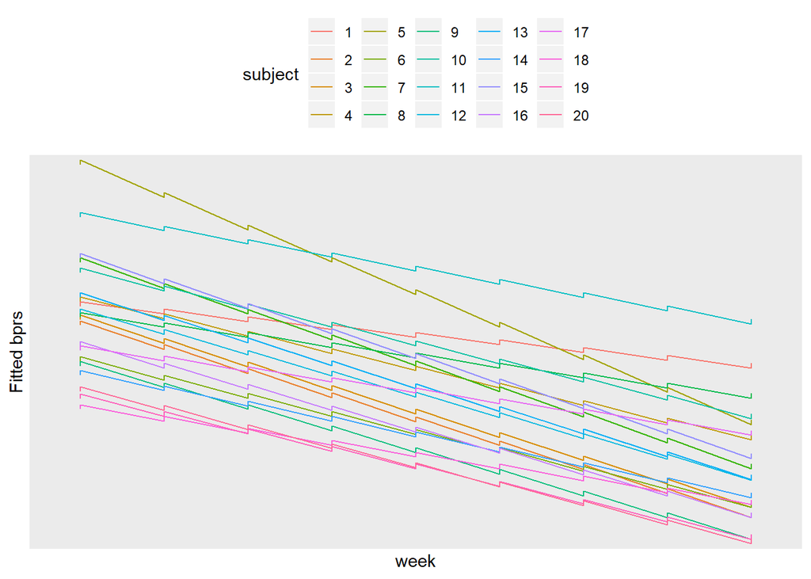

```r
Fitted <- fitted(BPRS_ref1)
BPRSL <- BPRSL %>%
  mutate(Fitted)

ggplot(BPRSL, aes(x = week, y = Fitted, group = subject)) +
  geom_line(aes(col = subject)) +
  scale_x_discrete(name = "week", breaks = seq(0, 8, 1)) +
  scale_y_discrete(name = "Fitted bprs") +

  theme(legend.position = "top")
```

[figure not shown]

```r
ggplot(BPRSL, aes(x = week, y = Fitted, group = treatment)) +
  geom_line(aes(col = treatment)) +
  scale_x_discrete(name = "week", breaks = seq(0, 8, 1)) +
  scale_y_discrete(name = "Fitted bprs") +

  theme(legend.position = "top")
```

## Boxplot

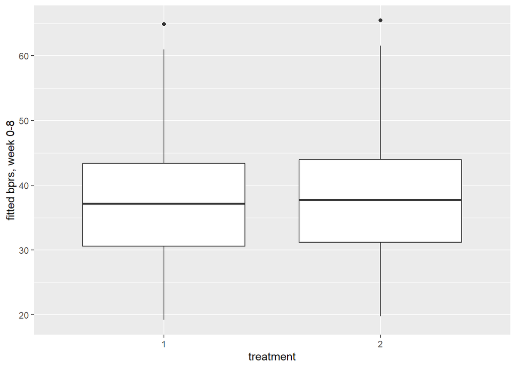

```r
library(ggplot2)
ggplot(BPRSL, aes(x = treatment, y = Fitted)) +
  geom_boxplot() +
  stat_summary(fun.y = "fitted bprs", geom = "point", shape=23, size=4, fill = "white") +
  scale_y_continuous(name = "fitted bprs, week 0-8")
```